# Stylized Facts

Personal Notes from the book [Financial Risk Modelling and Portfolio Optimization in R](https://www.amazon.com/Financial-Risk-Modelling-Portfolio-Optimization/dp/0470978708).

### Financial Market Data

First glance over the paper by [Campbell *et al*. 1997](http://www.proba.jussieu.fr/pageperso/ramacont/papers/empirical.pdf) to consider general issues with market returns.

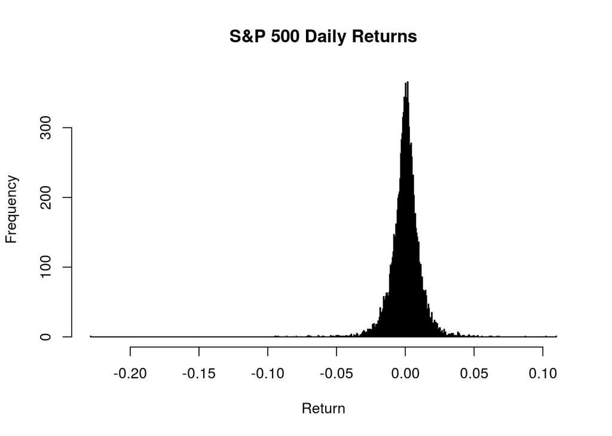

```r
library(quantmod)
snp = getSymbols("^GSPC", src = "yahoo", auto.assign = FALSE, from = "1970-01-01")
snp = na.omit(snp)

# Leptokurtic returns
hist(dailyReturn(snp, type = "log"), main = "S&P 500 Daily Returns", xlab = "Return",
    breaks = 500)
```

Look here for data on the [evir package](https://cran.r-project.org/web/packages/evir/index.html) and [fbasics package](https://cran.r-project.org/web/packages/fBasics/index.html).

- Time series data of returns, in particular daily return series, are in general not independent and identically distributed (i.i.d.). This fact is not jeopardized by low absolute values of the first-order autocorrelation coefficient.
- The volatility of return processes is not constant with respect to time.
- The absolute or squared returns are highly autocorrelated.
- The distribution of financial market returns is leptokurtic. The occurence of extreme events is more likely compared to the normal distribution.
- Extreme returns are observed closely in time (volatility clustering).
- The empirical distribution of returns is skewed to the left; negative returns are more likely to occur than positive ones.

### Chapter 3.1 Stylized facts for univariate series

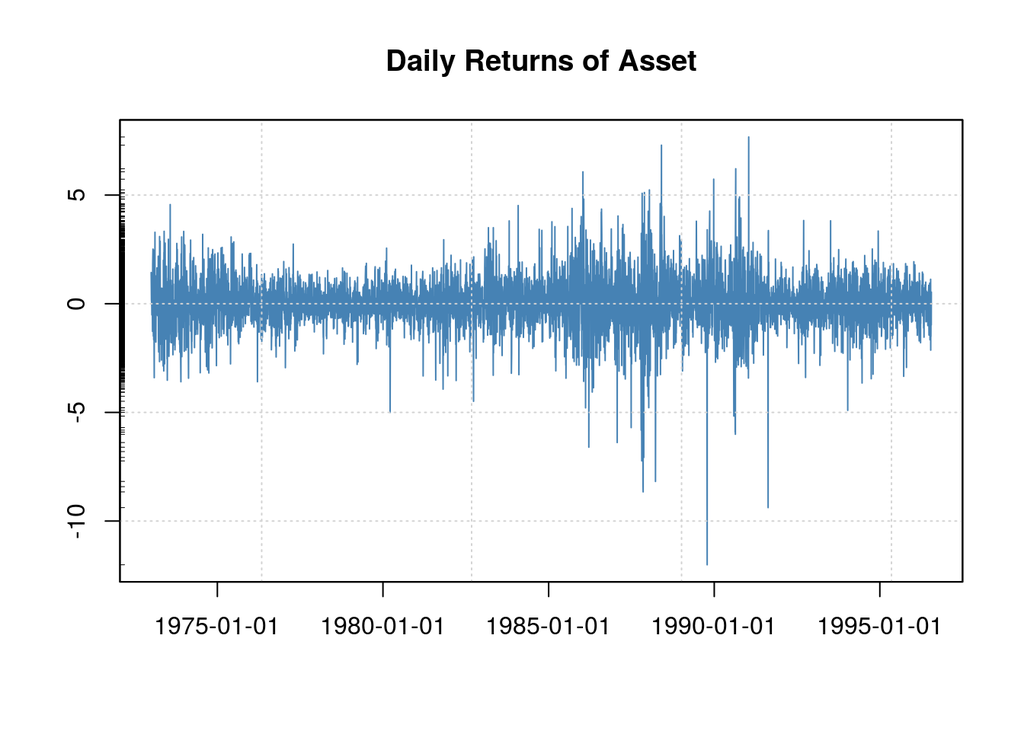

```r
library(fBasics)
library(quantmod)
######################## INPUTS ######################
asset_ticker = "AMZN"
max_date = "1990-01-01"
book_data = TRUE  # If true, asset_ticker will be ignored
######################################################

if (book_data == FALSE) {
    stock = getSymbols(asset_ticker, src = "yahoo", auto.assign = FALSE, from = max_date)
    asset_returns = as.vector(dailyReturn(stock, type = "log"))
    asset_dates = rownames(as.data.frame(stock))
    asset_returns = timeSeries(asset_returns, charvec = asset_dates)
} else {
    library(evir)
    data(siemens)
    sie_dates = as.character(format(as.POSIXct(attr(siemens, "times")), "%Y-%m-%d"))
    sie_returns = timeSeries(siemens * 100, charvec = sie_dates)
    colnames(sie_returns) = "siemens_returns"
    asset_returns = sie_returns
}


## Stylised Facts 1
seriesPlot(asset_returns, title = FALSE, main = "Daily Returns of Asset")
```

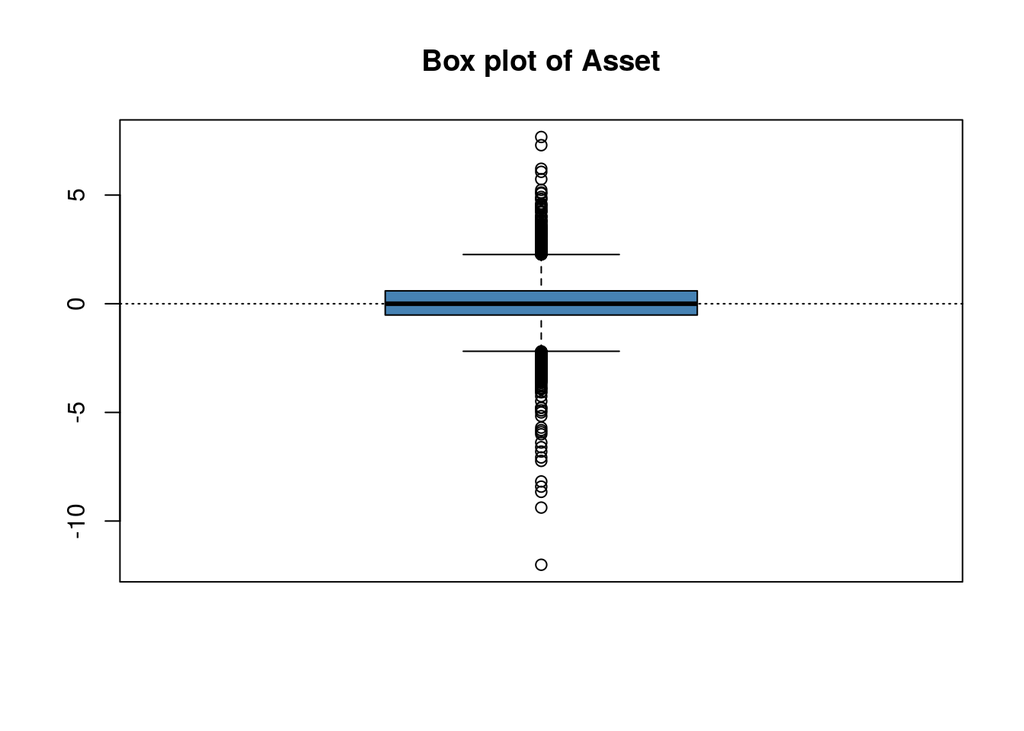

```r
boxPlot(asset_returns, title = FALSE, main = "Box plot of Asset")
```

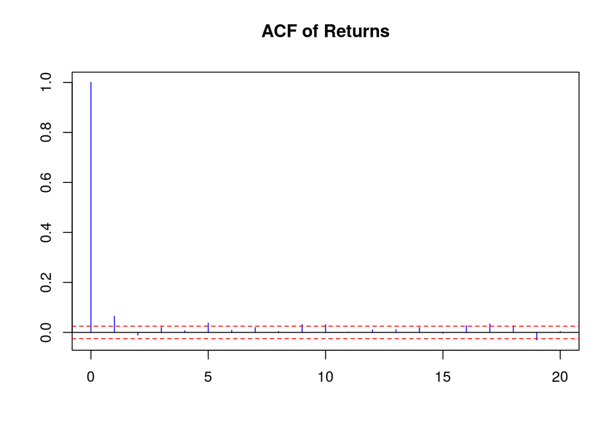

```r
acf(asset_returns, main = "ACF of Returns", lag.max = 20, ylab = "", xlab = "",
    col = "blue", ci.col = "red")
```

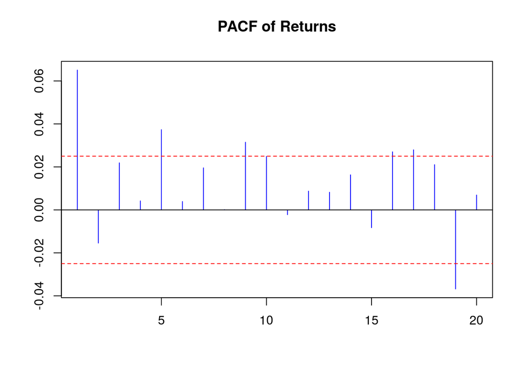

```r
pacf(asset_returns, main = "PACF of Returns", lag.max = 20, ylab = "", xlab = "",
    col = "blue", ci.col = "red")
```

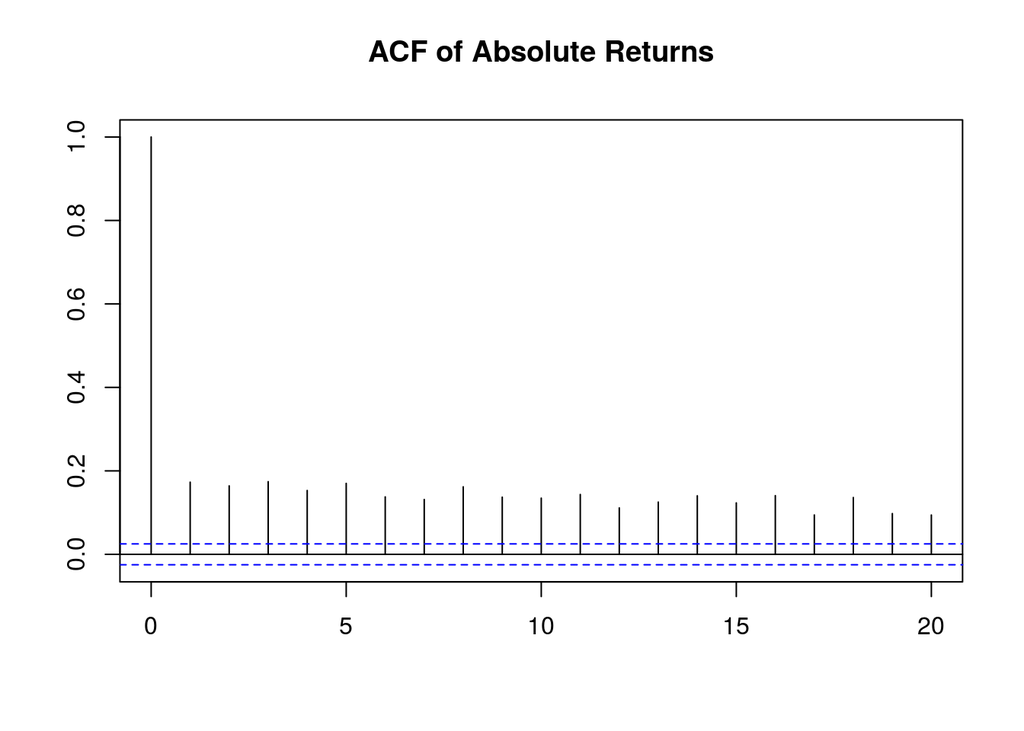

```r
## Stylised Facts II

asset_returns_abs = abs(asset_returns)

# selecting the 100th largest return
asset_returns_100 = tail(sort(abs(series(asset_returns))), 100)[1]

idx = which(series(asset_returns_abs) > asset_returns_100, arr.ind = TRUE)

asset_returns_abs_100 = timeSeries(rep(0, length(asset_returns)), charvec = time(asset_returns))
asset_returns_abs_100[idx, 1] = asset_returns_abs[idx]
acf(asset_returns_abs, main = "ACF of Absolute Returns", lag.max = 20, ylab = "",
    xlab = "")
```

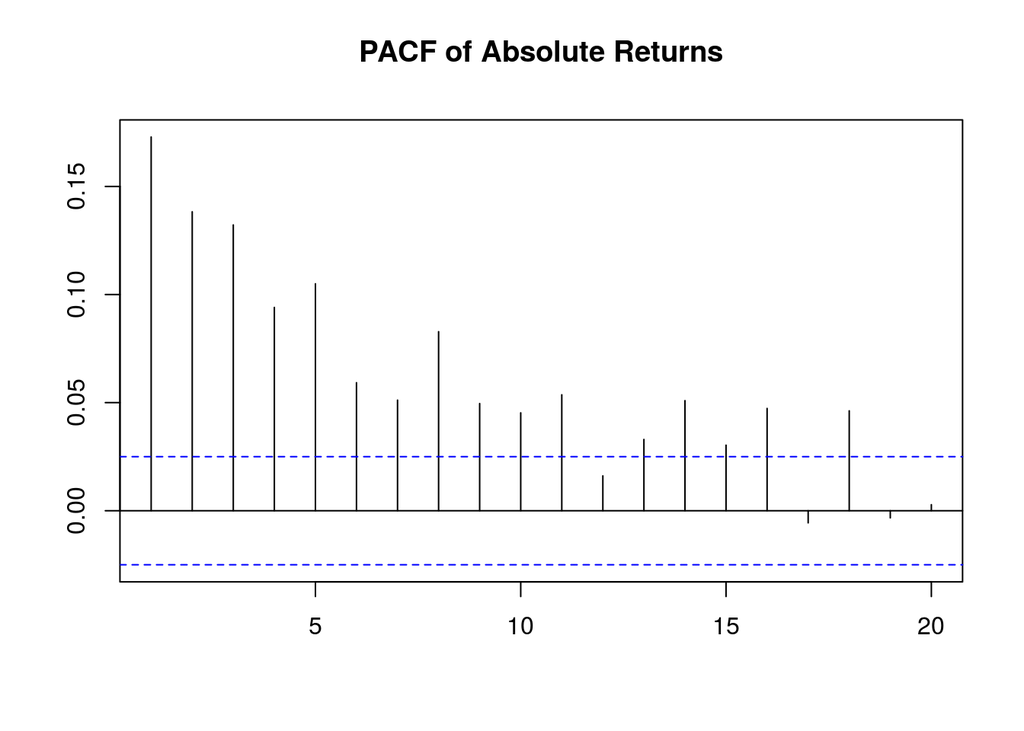

```r
pacf(asset_returns_abs, main = "PACF of Absolute Returns", lag.max = 20, ylab = "",
    xlab = "")
```

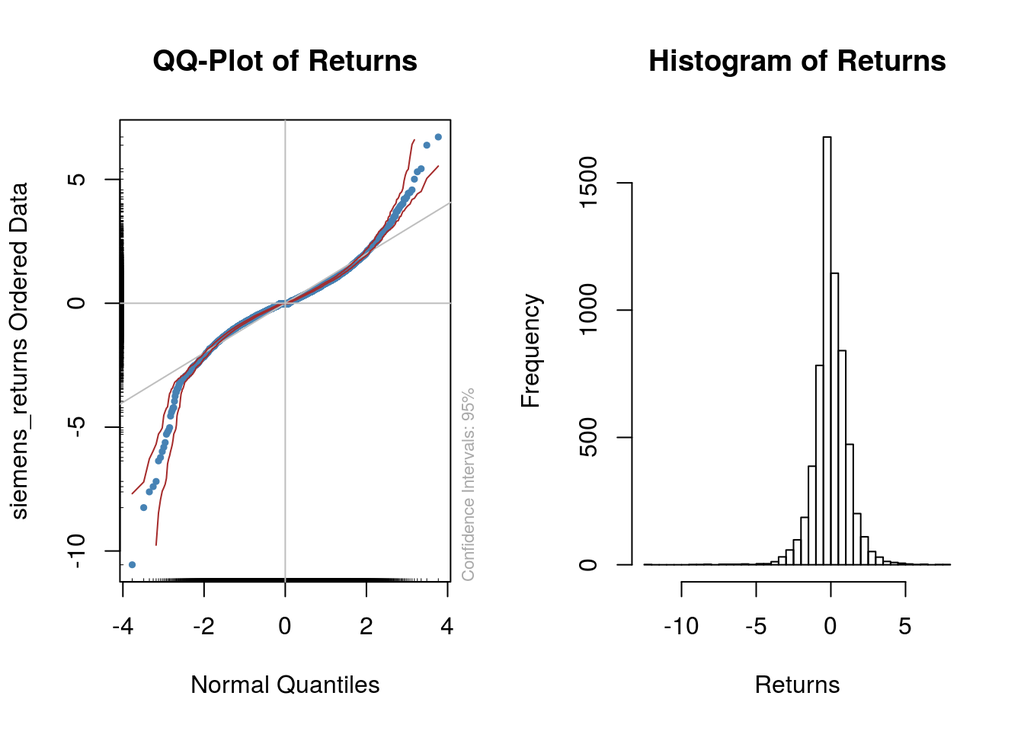

```r
par(mfrow = c(1, 2))
qqnormPlot(asset_returns, main = "QQ-Plot of Returns", title = FALSE, cex = 0.5,
    pch = 19)
hist(asset_returns, main = "Histogram of Returns", breaks = 50, xlab = "Returns")
```

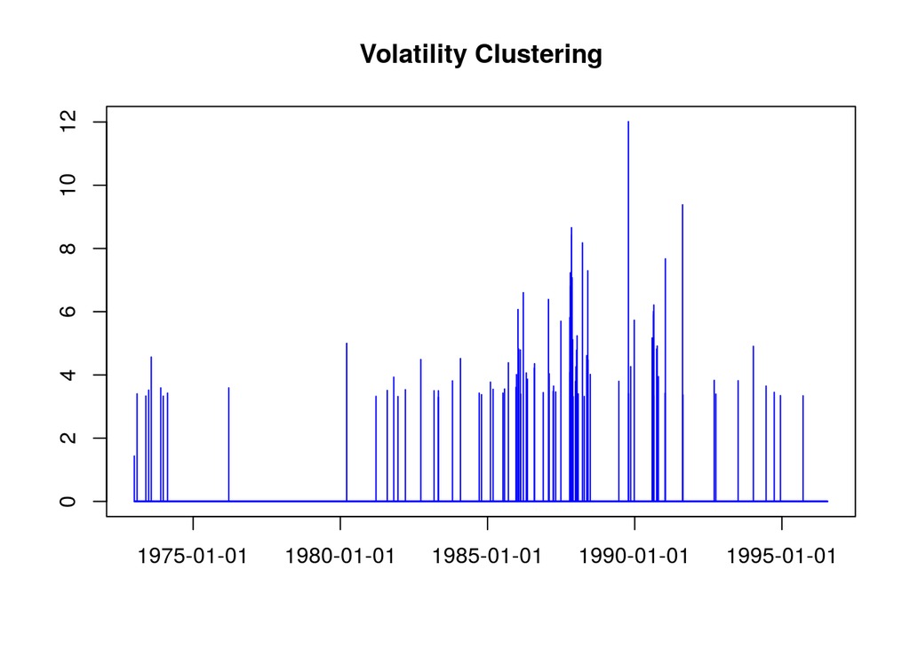

```r
par(mfrow = c(1, 1))
plot(asset_returns_abs_100, type = "h", main = "Volatility Clustering", ylab = "",
    xlab = "", col = "blue")
```

### Chapter 3.1.2 Stylized facts for multivariate series

- The absolute value of cross-correlations between return series is less pronounced and the contemporanous correlations are in general the strongest.
- In contrast, the absolute value or squared returns do show high cross-correlations. This empirical finding is similar to the univariate case.
- The contemporaneous correlations are not constant over time.
- Extreme observations in one return series are often accompanied by extremes in the other return series.

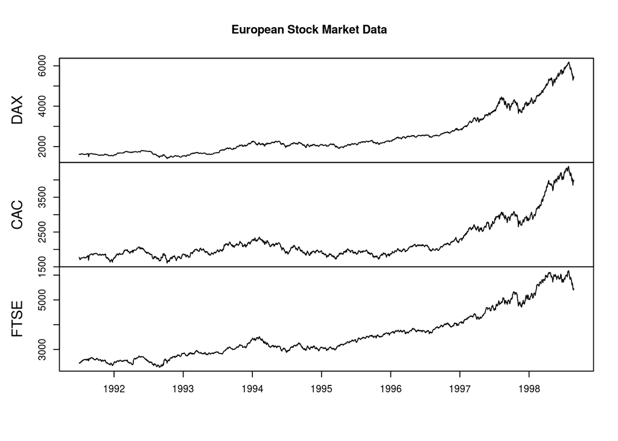

```r
# Stylized facts for European Stock Market

library(zoo)
data(EuStockMarkets)

# Time series plot of levels
eu_stock_level = as.zoo(EuStockMarkets)[, c("DAX", "CAC", "FTSE")]
plot(eu_stock_level, xlab = "", main = "European Stock Market Data")
```

```r
# Percentage returns
eu_stock_returns = diff(log(eu_stock_level)) * 100
```

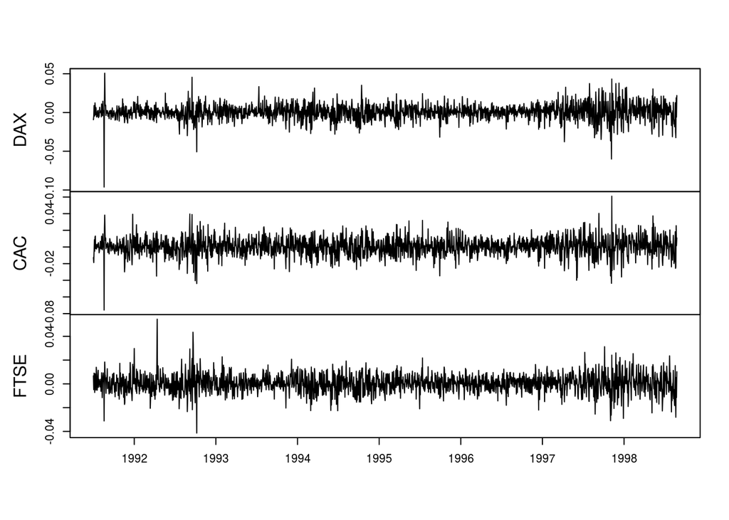

```r
# I get different values when using the dailyReturn function from quantmod
# as compared to the function below. When calculating log returns, don't do
# it the way I'm about to.  I'm going with the authors code but I'm not
# convinced it's correct.
eu_stock_returns = diff(log(eu_stock_level))
plot(eu_stock_returns, xlab = "", main = "")
```